# Analysis for Trailmaking

Cooper

2023-07-31

# 1 Introduction:

This R markdown file would be used to do statistical analysis for trailmaking test. It contains two main parts. In the first part, this file presents R code used to clean dataset. In the second part, this file presents some summary tables according to different regression models.

# 2 Apple Watch Data and GAPCare II Dataset - Baseline

After we have cleaned apple watch data of trailmaking, we need to choose the Baseline data. There is a csv file recording the relationship between the GAPCare II dataset and apple watch data and also recording the 30-days-followup, 60-days-followup, 90-days-followup, and baseline timelines. Here, we only care about baseline dataset.

```r
library(tidyverse)
library(dplyr)
library(readxl)
library(car)
library(jtools)
library(huxtable)
library(knitr)
library(MASS)

#Import Dataset
Stroop_data_original <- read.csv("/Users/dhyscuduke/Desktop/Cleaned_Data_New_Cognition/Cognition_stroop_new.csv")
Trailmaking_data_original <- read.csv("/Users/dhyscuduke/Desktop/Cleaned_Data_New_Cognition/Cognition_trailmakingtest_new.csv")
GAPCare2 <- read.csv("/Volumes/GoldbergLab/GAPCare II/Data/GAPcare II Clinical Trial/GAPcareIIClinicalTri_DATA_LABELS_2023-05-03_1711.csv")
ID_Data <- read.csv("/Users/dhyscuduke/Desktop/GAPcare II Login info - 02.15.2023.csv")

#ID_Data <- select(ID_Data, REDCap.ID, ED.Apple.Watch.Fall.ID)
```

Here is R Code for baseline dataset screened in trailmaking test:

```r
#Trailmaking Baseline Screeded
R2 <- as.vector(Trailmaking_data_original$pt)
Trailmaking_data_original$selected_nums_trail<- sub("(\\d{16}).*", "\\1", R2)
Baseline_trail <- Trailmaking_data_original[Trailmaking_data_original$selected_nums_trail
                                            %in% ID_Data$ED.Apple.Watch.Fall.ID, ]
ID2 <- as.vector(Baseline_trail$selected_nums_trail)[!duplicated(as.vector(Baseline_trail$selected_nums_trail))]
selected_ID_Data2 <- ID_Data[ID_Data$ED.Apple.Watch.Fall.ID %in% ID2,]
```

# 3 Trailmaking Test

In this section, we focus on specific data needed for trailmaking test.

## 3.1 Trailmaking Test

```r
#Trailmaking Analysis

Baseline_trail<- Baseline_trail %>%
  group_by(pt) %>% slice(which.max(Timestamp))

for (i in 1:length(Baseline_trail$pt)){
  Baseline_trail$ID[i] <- (selected_ID_Data2
                           %>% filter(ED.Apple.Watch.Fall.ID
                                      == Baseline_trail$selected_nums_trail[i]))$REDCap.ID
}

head(Baseline_trail)
```

```
## # A tibble: 6 × 7
## # Groups:   pt [6]
##   pt                                 Times…¹ Index Incor…² No.Er…³ selec…⁴ ID
##   <chr>                                <dbl> <int>   <int>   <int> <chr>   <chr>
## 1 4658593351598080_active_tasks_1_a…    60.2    12       0       1 465859… 1889
## 2 4658593351598080_active_tasks_2_a…    43.1    12       0       0 465859… 1889
## 3 4658593351598080_active_tasks_3_a…    61.0    12       0       1 465859… 1889
## 4 4658593351598080_active_tasks_4_a…    42.2    12       0       1 465859… 1889
## 5 4774271542886400_active_tasks_1_a…   152.     12       0       9 477427… 959
## 6 4811078900908032_active_tasks_1_a…   179.     12       0      18 481107… 1131
## # … with abbreviated variable names ¹Timestamp, ²Incorrect, ³No.Errors,
## #   ⁴selected_nums_trail
```

# 4 Covariates

Before doing regression analysis, we need to consider the confounders used in regression model. Let $Age_{ij}$ , $Male_i$, $Education_i$, $Assistive Device_{ij}$ , $Fall History_i$, $Head Strike_i$, and $Cognitive Impairment_i$ similarly denote a participant’s age, indicator for gender male, education in years, use of an assistive device for walking, indicator for fall history at initial ED visit, head strike associated with presenting fall, and cognitive impairment as measured by answering three or more of the six item screener questions incorrectly, respectively. We created and cleaned these confounders in R:

```r
#Filter Age, Gender, EDU, Cognitive Impairment, Head Strike, Fall History, and Assistive Devices
GAPCare_Data_trail <- GAPCare2 %>% filter(Event.Name == 'ED Visit ') #Filter ED Visit
for (i in 1:length(Baseline_trail$pt)){
  Baseline_trail$Age[i] <- (GAPCare_Data_trail
                            %>% filter(Record.ID
                                       == Baseline_trail$ID[i]))$How.old.is.the.patient.as.listed.in.the.chart.
  Baseline_trail$Gender[i] <- (GAPCare_Data_trail
                               %>% filter(Record.ID
                                          == Baseline_trail$ID[i]))$What.is.the.gender.of.the.patient.as.listed.in.the.chart.
  Baseline_trail$Education[i] <- (GAPCare_Data_trail
                                  %>% filter(Record.ID
                                             == Baseline_trail$ID[i]))$What.is.the.highest.grade.or.year.of.school.you.completed.
  Baseline_trail$Device[i] <- (GAPCare_Data_trail
                               %>% filter(Record.ID
                                          == Baseline_trail$ID[i]))$Do.you.use.any.special.equipment..such.as.a.cane..a.walker..a.wheelchair..a.special.bed..or.a.special.telephone..include.occasional.use.or.use.in.certain.circumstances..
  Baseline_trail$Intervention[i] <- (GAPCare_Data_trail
                                     %>% filter(Record.ID
                                                == Baseline_trail$ID[i]))$Randomize.Patient
  Baseline_trail$head[i] <- (GAPCare_Data_trail
                              %>% filter(Record.ID
                                         == Baseline_trail$ID[i]))$If.yes..what.injuries.did.you.have..Select.all.that.apply....choice.Loss.of.consciousness.
}
```

```r
for (i in 1:length(Baseline_trail$pt)){
  Baseline_trail$Fall[i] <- (GAPCare_Data_trail
                              %>% filter(Record.ID
                                         == Baseline_trail$ID[i]))$Were.you.hurt..
  Baseline_trail$sis_1a[i] <- (GAPCare_Data_trail
                                %>% filter(Record.ID
                                           == Baseline_trail$ID[i]))$APPLE..recall..
  Baseline_trail$sis_1b[i] <- (GAPCare_Data_trail
                                %>% filter(Record.ID
                                           == Baseline_trail$ID[i]))$APPLE..recall...1
  Baseline_trail$sis_2a[i] <- (GAPCare_Data_trail
                                %>% filter(Record.ID
                                           == Baseline_trail$ID[i]))$TABLE..recall..
  Baseline_trail$sis_2b[i] <- (GAPCare_Data_trail
                                %>% filter(Record.ID
                                           == Baseline_trail$ID[i]))$TABLE..recall...1
  Baseline_trail$sis_3a[i] <- (GAPCare_Data_trail
                                %>% filter(Record.ID
                                           == Baseline_trail$ID[i]))$CAR..recall..
  Baseline_trail$sis_3b[i] <- (GAPCare_Data_trail
                                %>% filter(Record.ID
                                           == Baseline_trail$ID[i]))$CAR..recall...1
  Baseline_trail$sis_4[i] <- (GAPCare_Data_trail
                               %>% filter(Record.ID
                                          == Baseline_trail$ID[i]))$READ..What.is.the.year....Correct..
  Baseline_trail$sis_5[i] <- (GAPCare_Data_trail
                               %>% filter(Record.ID
                                          == Baseline_trail$ID[i]))$READ..What.is.the.month....Correct..
  Baseline_trail$sis_6[i] <- (GAPCare_Data_trail
                               %>% filter(Record.ID
                                          == Baseline_trail$ID[i]))$READ..What.is.the.day.of.the.week....Correct..
}
```

# 5 Regression Models

## 5.1 Balance and Outliers

Before doing regression analysis, we need to delete any outlier in response variable and balance all explanatory variables. After drawing the histogram of Timestamp, we found there is a value which is nearly 500 and larger a lot than other Timestamp values. Therefore, we think this is an accident and the outlier should be deleted. The reason why this patient(1168; 5967235711500288) took so long time I guessed is that the patient was 95 and he had to use lots of time to judge the distance between two numbers. The number of incorrects for this patient is only 6 which proves he had tried his best to connect each number correctly only once.

On the other hand, the distribution of Timestamp has a heavy tail. Hence, I will use negative binomial regression model (glm.nb in R) to do the analysis.

The plots of distribution:

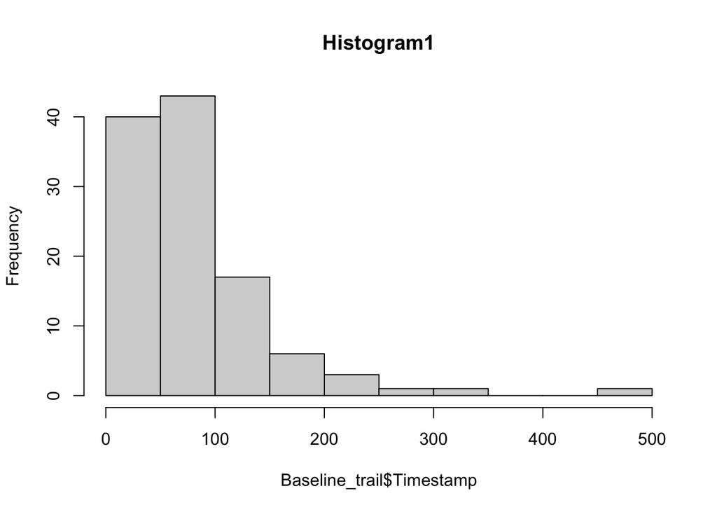

```r
hist(Baseline_trail$Timestamp, main="Histogram1")
```

Now, let’s consider the balance of explanatory variables. After checking all variables, I found variable education has an incorrect value “Do not know” and variable Fall has an incorrect value “Don’t Know”. The patients of the two incorrect values should not be involved in further analysis. On the other hand, the six item screener questions should be combined into one variable. If the value of one screener is ‘yes’, we rewrite it as 1. If the value of one screener is ‘no’, we rewrite it as 0. Then, sum all 1s and 0s together to get the variable sis. The code is shown below:

```r
Baseline_trail <- filter(Baseline_trail, Timestamp < 400)
Baseline_trail <- filter(Baseline_trail, Education != "Do not know")
Baseline_trail <- filter(Baseline_trail, Fall != "Don't Know")

sis <- rep(0,length(Baseline_trail$pt))
for (i in 1:length(Baseline_trail$Age)){
  if (Baseline_trail$sis_1a[i] == "Yes"){
    sis[i] = sis[i] + 1
  }
  if (Baseline_trail$sis_2a[i] == "Yes"){
    sis[i] = sis[i] + 1
  }
  if (Baseline_trail$sis_3a[i] == "Yes"){
    sis[i] = sis[i] + 1
  }
  if (Baseline_trail$sis_1b[i] == "Yes"){
    sis[i] = sis[i] + 1
  }
  if (Baseline_trail$sis_2b[i] == "Yes"){
    sis[i] = sis[i] + 1
  }
  if (Baseline_trail$sis_3b[i] == "Yes"){
    sis[i] = sis[i] + 1
  }
  if (Baseline_trail$sis_4[i] == "Yes"){
    sis[i] = sis[i] + 1
  }
  if (Baseline_trail$sis_5[i] == "Yes"){
    sis[i] = sis[i] + 1
  }
  if (Baseline_trail$sis_6[i] == "Yes"){
    sis[i] = sis[i] + 1
  }
}
Baseline_trail$sis <- sis
```

## 5.2 Preprocessing of Categorical and Counting Variables

```r
#Preprocessing for categorical variables and counting variables
Gender_1 <- factor(Baseline_trail$Gender)
dummy_Gender <- model.matrix(~ Gender_1 - 1)
Baseline_trail$dummy_Gender <- dummy_Gender

Edu_1 <- factor(Baseline_trail$Education)
dummy_Education <- model.matrix(~ Edu_1 - 1)
Baseline_trail$dummy_Education <- dummy_Education

Inter_1 <- factor(Baseline_trail$Intervention)
dummy_Intervention <- model.matrix(~ Inter_1 - 1)
Baseline_trail$dummy_Intervention <- dummy_Intervention

head_1 <- factor(Baseline_trail$head)
dummy_head <- model.matrix(~ head_1 - 1)
Baseline_trail$dummy_head <- dummy_head

Device_1 <- factor(Baseline_trail$Device)
dummy_Device <- model.matrix(~ Device_1 - 1)
Baseline_trail$dummy_Device <- dummy_Device

Fall_1 <- factor(Baseline_trail$Fall)
dummy_Fall <- model.matrix(~ Fall_1 - 1)
Baseline_trail$dummy_Fall <- dummy_Fall
```

## 5.3 Regression models for trailmaking test

Below contain all regression models:

$$E[TMT_{i1}]=\beta_0+\beta_1Age_{i1}+\beta_2Male_i+\beta_3Education_i$$
$$E[TMT_{i1}]=\beta_0+\beta_1Assistive
Device_{i1}+\beta_2Age_{i1}+\beta_2Male_i+\beta_2Education_i$$

$$E[TMT_{i1}]=\beta_0+\beta_1Cognitive
Impairment_{i1}+\beta_2Age_{i1}+\beta_2Male_i+\beta_2Education_i$$

$$E[TMT_{i1}]=\beta_0+\beta_1Head
Strike_{i1}+\beta_2Age_{i1}+\beta_2Male_i+\beta_2Education_i$$

$$E[TMT_{i1}]=\beta_0+\beta_1Fall
History_{i1}+\beta_2Age_{i1}+\beta_2Male_i+\beta_2Education_i$$

```r
#Regression models
model1_p <- glm.nb(Timestamp ~ Age + Gender + Education, data=Baseline_trail)
model2_p <- glm.nb(Timestamp ~ Age + Gender + Education + Device, data=Baseline_trail)
model3_p <- glm.nb(Timestamp ~ Age + Gender + Education + sis, data=Baseline_trail)
model4_p <- glm.nb(Timestamp ~ Age + Gender + Education + head, data=Baseline_trail)
model5_p <- glm.nb(Timestamp ~ Age + Gender + Education + Fall, data=Baseline_trail)

#Regression models
model1 <- glm.nb(Timestamp ~ Age + dummy_Gender + dummy_Education, data=Baseline_trail)
model2 <- glm.nb(Timestamp ~ Age + dummy_Gender + dummy_Education + dummy_Device, data=Baseline_trail)
model3 <- glm.nb(Timestamp ~ Age + dummy_Gender + dummy_Education + sis, data=Baseline_trail)
model4 <- glm.nb(Timestamp ~ Age + dummy_Gender + dummy_Education + dummy_head, data=Baseline_trail)
model5 <- glm.nb(Timestamp ~ Age + dummy_Gender + dummy_Education + dummy_Fall, data=Baseline_trail)
```

## 5.4 Check Assumptions for Regression Models

Even if we have built our models, we should check some assumptions for these models before using their outcomes. Firstly, we should check the collinearity and independence of explanatory variables. For collinearity, I used variance inflation factor to check. In general, the VIF should be near 1 and not to large. All VIFs in all five models are between 1.0 to 1.3 which are good enough. For the independence, I used Durbin–Watson statistic to check. In general, the Durbin–Watson statistic should be near 2. The Durbin–Watson statistic for five models are all 2 which are also good enough. Therefore, the assumptions of collinearity and independence are satisfied.

```r
#Durbin-Watson
D1 <- durbinWatsonTest(model1)
D2 <- durbinWatsonTest(model2)
D3 <- durbinWatsonTest(model3)
D4 <- durbinWatsonTest(model4)
D5 <- durbinWatsonTest(model5)

#VIF Score
DD1 <- car::vif(model1_p)
DD2 <- car::vif(model2_p)
DD3 <- car::vif(model3_p)
DD4 <- car::vif(model4_p)
DD5 <- car::vif(model5_p)
```

Secondly, we should check the residual plots and qqplots for each model. In general, the residual line should follow the line $y=0$ and the line in qqplot should follow $y=x$. The plots for each model are shown below.

Residual plots:

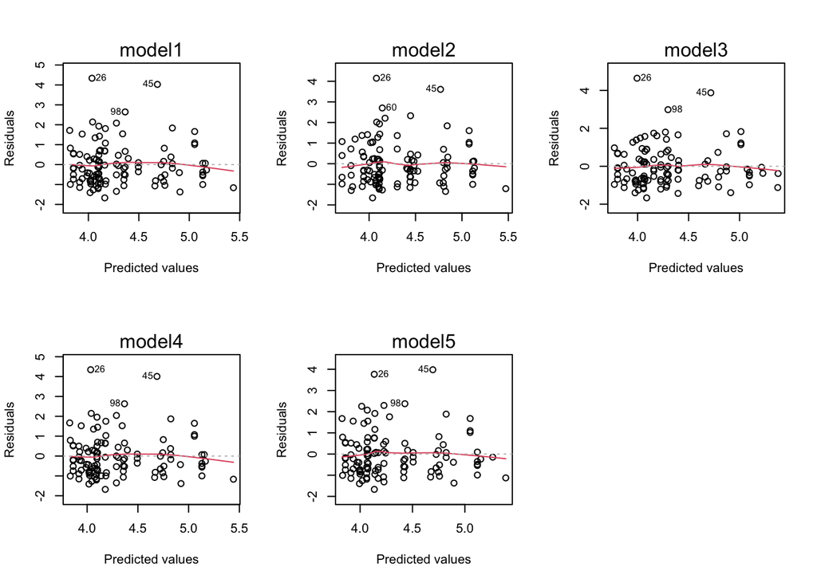

```r
par(mfrow=c(2,3))
plot(model1, which = 1, xlab("model1")) #Residual plot
plot(model2, which = 1, xlab("model2")) #Residual plot
plot(model3, which = 1, xlab("model3")) #Residual plot
plot(model4, which = 1, xlab("model4")) #Residual plot
plot(model5, which = 1, xlab("model5")) #Residual plot
```

Q-Q plots:

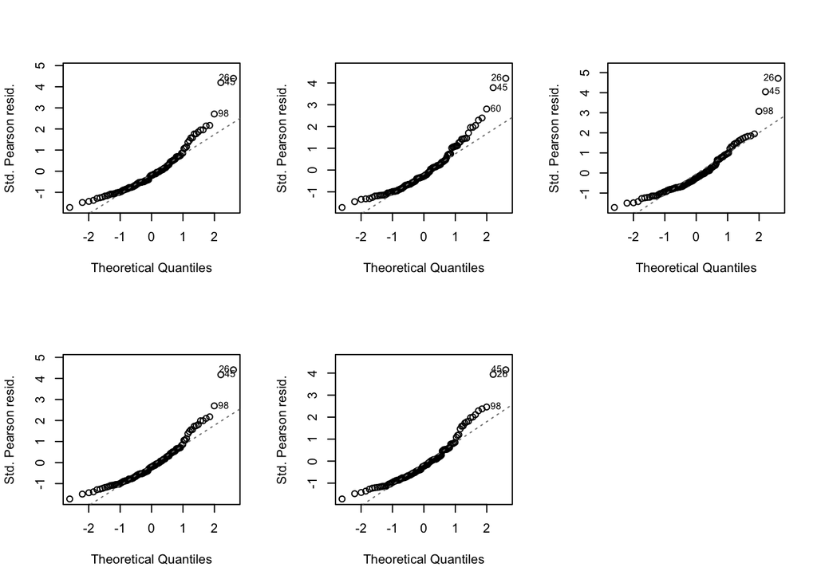

```r
par(mfrow=c(2,3))
plot(model1, which = 2, xlab("model1")) #Normality plot
plot(model2, which = 2, xlab("model2")) #Normality plot
plot(model3, which = 2, xlab("model3")) #Normality plot
plot(model4, which = 2, xlab("model4")) #Normality plot
plot(model5, which = 2, xlab("model5")) #Normality plot
```

## 5.5 Outcomes for regression models of trailmaking test

Outcomes for model 1:

```r
summary(model1)
```

```
##
## Call:
## glm.nb(formula = Timestamp ~ Age + dummy_Gender + dummy_Education,
##     data = Baseline_trail, init.theta = 3.959757788, link = log)
##
## Deviance Residuals:
##     Min       1Q   Median       3Q      Max
## -2.8081  -0.8820  -0.1969   0.4494   2.8453
##
## Coefficients: (2 not defined because of singularities)
##                                                                                   Estimate
## (Intercept)                                                                       4.918840
## Age                                                                               0.006177
## dummy_GenderGender_1Female                                                       -0.266978
## dummy_GenderGender_1Male                                                                NA
## dummy_EducationEdu_1College 1 year to 3 years (Some college or technical school) -1.238620
## dummy_EducationEdu_1College 4 years or more (College graduate)                   -1.067228
## dummy_EducationEdu_1Grades 1 through 8 (Elementary/middle school)                -0.619460
## dummy_EducationEdu_1Grades 12 or GED (High school graduate)                      -0.424814
## dummy_EducationEdu_1Grades 9 through 11 (Some high school)                              NA
##                                                                                  Std. Error
## (Intercept)                                                                        0.554692
## Age                                                                                0.006942
## dummy_GenderGender_1Female                                                         0.112195
## dummy_GenderGender_1Male                                                                 NA
## dummy_EducationEdu_1College 1 year to 3 years (Some college or technical school)   0.186146
## dummy_EducationEdu_1College 4 years or more (College graduate)                     0.171912
## dummy_EducationEdu_1Grades 1 through 8 (Elementary/middle school)                  0.299411
## dummy_EducationEdu_1Grades 12 or GED (High school graduate)                        0.206400
## dummy_EducationEdu_1Grades 9 through 11 (Some high school)                               NA
##                                                                                  z value
## (Intercept)                                                                        8.868
## Age                                                                                0.890
## dummy_GenderGender_1Female                                                        -2.380
## dummy_GenderGender_1Male                                                              NA
## dummy_EducationEdu_1College 1 year to 3 years (Some college or technical school)  -6.654
## dummy_EducationEdu_1College 4 years or more (College graduate)                    -6.208
## dummy_EducationEdu_1Grades 1 through 8 (Elementary/middle school)                 -2.069
## dummy_EducationEdu_1Grades 12 or GED (High school graduate)                       -2.058
## dummy_EducationEdu_1Grades 9 through 11 (Some high school)                            NA
```

[output cut: 21 more lines]

```
## Signif. codes:  0 '***' 0.001 '**' 0.01 '*' 0.05 '.' 0.1 ' ' 1
##
## (Dispersion parameter for Negative Binomial(3.9598) family taken to be 1)
##
##     Null deviance: 181.10  on 108  degrees of freedom
## Residual deviance: 113.15  on 102  degrees of freedom
## AIC: 1100.9
##
## Number of Fisher Scoring iterations: 1
##
##
##               Theta:  3.960
##           Std. Err.:  0.549
##
##  2 x log-likelihood:  -1084.915
```

Outcomes for model 2:

```r
summary(model2)
```

```
##
## Call:
## glm.nb(formula = Timestamp ~ Age + dummy_Gender + dummy_Education +
##     dummy_Device, data = Baseline_trail, init.theta = 4.107314246,
##     link = log)
##
## Deviance Residuals:
##     Min       1Q   Median       3Q      Max
## -2.7058  -0.9036  -0.2829   0.3968   2.7672
##
## Coefficients: (3 not defined because of singularities)
##                                                                                   Estimate
## (Intercept)                                                                       5.221569
## Age                                                                               0.002982
## dummy_GenderGender_1Female                                                       -0.337861
## dummy_GenderGender_1Male                                                                NA
## dummy_EducationEdu_1College 1 year to 3 years (Some college or technical school) -1.154014
## dummy_EducationEdu_1College 4 years or more (College graduate)                   -1.022594
## dummy_EducationEdu_1Grades 1 through 8 (Elementary/middle school)                -0.624122
## dummy_EducationEdu_1Grades 12 or GED (High school graduate)                      -0.335116
## dummy_EducationEdu_1Grades 9 through 11 (Some high school)                              NA
## dummy_DeviceDevice_1No                                                           -0.262671
## dummy_DeviceDevice_1Yes                                                                 NA
##                                                                                  Std. Error
## (Intercept)                                                                        0.575074
## Age                                                                                0.007125
## dummy_GenderGender_1Female                                                         0.114165
## dummy_GenderGender_1Male                                                                 NA
## dummy_EducationEdu_1College 1 year to 3 years (Some college or technical school)   0.188050
## dummy_EducationEdu_1College 4 years or more (College graduate)                     0.170319
## dummy_EducationEdu_1Grades 1 through 8 (Elementary/middle school)                  0.294207
## dummy_EducationEdu_1Grades 12 or GED (High school graduate)                        0.209817
## dummy_EducationEdu_1Grades 9 through 11 (Some high school)                               NA
## dummy_DeviceDevice_1No                                                             0.129201
## dummy_DeviceDevice_1Yes                                                                  NA
##                                                                                  z value
## (Intercept)                                                                        9.080
## Age                                                                                0.418
## dummy_GenderGender_1Female                                                        -2.959
## dummy_GenderGender_1Male                                                              NA
```

[output cut: 32 more lines]

```
## Signif. codes:  0 '***' 0.001 '**' 0.01 '*' 0.05 '.' 0.1 ' ' 1
##
## (Dispersion parameter for Negative Binomial(4.1073) family taken to be 1)
##
##     Null deviance: 187.45  on 108  degrees of freedom
## Residual deviance: 113.00  on 101  degrees of freedom
## AIC: 1098.9
##
## Number of Fisher Scoring iterations: 1
##
##
##               Theta:  4.107
##           Std. Err.:  0.571
##
##  2 x log-likelihood:  -1080.889
```

Outcomes for model 3:

```r
summary(model3)
```

```
##
## Call:
## glm.nb(formula = Timestamp ~ Age + dummy_Gender + dummy_Education +
##     sis, data = Baseline_trail, init.theta = 4.054223828, link = log)
##
## Deviance Residuals:
##     Min       1Q   Median       3Q      Max
## -2.7514  -0.8352  -0.2487   0.5750   2.9996
##
## Coefficients: (2 not defined because of singularities)
##                                                                                   Estimate
## (Intercept)                                                                       5.682773
## Age                                                                               0.006384
## dummy_GenderGender_1Female                                                       -0.239873
## dummy_GenderGender_1Male                                                                NA
## dummy_EducationEdu_1College 1 year to 3 years (Some college or technical school) -1.247489
## dummy_EducationEdu_1College 4 years or more (College graduate)                   -1.069856
## dummy_EducationEdu_1Grades 1 through 8 (Elementary/middle school)                -0.675048
## dummy_EducationEdu_1Grades 12 or GED (High school graduate)                      -0.446739
## dummy_EducationEdu_1Grades 9 through 11 (Some high school)                              NA
## sis                                                                              -0.093835
##                                                                                  Std. Error
## (Intercept)                                                                        0.715351
## Age                                                                                0.006866
## dummy_GenderGender_1Female                                                         0.112825
## dummy_GenderGender_1Male                                                                 NA
## dummy_EducationEdu_1College 1 year to 3 years (Some college or technical school)   0.184107
## dummy_EducationEdu_1College 4 years or more (College graduate)                     0.169952
## dummy_EducationEdu_1Grades 1 through 8 (Elementary/middle school)                  0.297603
## dummy_EducationEdu_1Grades 12 or GED (High school graduate)                        0.204125
## dummy_EducationEdu_1Grades 9 through 11 (Some high school)                               NA
## sis                                                                                0.057137
##                                                                                  z value
## (Intercept)                                                                        7.944
## Age                                                                                0.930
## dummy_GenderGender_1Female                                                        -2.126
## dummy_GenderGender_1Male                                                              NA
## dummy_EducationEdu_1College 1 year to 3 years (Some college or technical school)  -6.776
## dummy_EducationEdu_1College 4 years or more (College graduate)                    -6.295
## dummy_EducationEdu_1Grades 1 through 8 (Elementary/middle school)                 -2.268
```

[output cut: 26 more lines]

```
## Signif. codes:  0 '***' 0.001 '**' 0.01 '*' 0.05 '.' 0.1 ' ' 1
##
## (Dispersion parameter for Negative Binomial(4.0542) family taken to be 1)
##
##     Null deviance: 185.17  on 108  degrees of freedom
## Residual deviance: 113.04  on 101  degrees of freedom
## AIC: 1100.3
##
## Number of Fisher Scoring iterations: 1
##
##
##               Theta:  4.054
##           Std. Err.:  0.563
##
##  2 x log-likelihood:  -1082.302
```

Outcomes for model 4:

```r
summary(model4)
```

```
##
## Call:
## glm.nb(formula = Timestamp ~ Age + dummy_Gender + dummy_Education +
##     dummy_head, data = Baseline_trail, init.theta = 3.967603325,
##     link = log)
##
## Deviance Residuals:
##     Min       1Q   Median       3Q      Max
## -2.8295  -0.8907  -0.2059   0.4630   2.8505
##
## Coefficients: (3 not defined because of singularities)
##                                                                                   Estimate
## (Intercept)                                                                       4.964791
## Age                                                                               0.005676
## dummy_GenderGender_1Female                                                       -0.276578
## dummy_GenderGender_1Male                                                                NA
## dummy_EducationEdu_1College 1 year to 3 years (Some college or technical school) -1.228957
## dummy_EducationEdu_1College 4 years or more (College graduate)                   -1.067897
## dummy_EducationEdu_1Grades 1 through 8 (Elementary/middle school)                -0.619787
## dummy_EducationEdu_1Grades 12 or GED (High school graduate)                      -0.420244
## dummy_EducationEdu_1Grades 9 through 11 (Some high school)                              NA
## dummy_headhead_1Checked                                                          -0.189973
## dummy_headhead_1Unchecked                                                               NA
##                                                                                  Std. Error
## (Intercept)                                                                        0.563556
## Age                                                                                0.007024
## dummy_GenderGender_1Female                                                         0.113852
## dummy_GenderGender_1Male                                                                 NA
## dummy_EducationEdu_1College 1 year to 3 years (Some college or technical school)   0.187087
## dummy_EducationEdu_1College 4 years or more (College graduate)                     0.171769
## dummy_EducationEdu_1Grades 1 through 8 (Elementary/middle school)                  0.299133
## dummy_EducationEdu_1Grades 12 or GED (High school graduate)                        0.206276
## dummy_EducationEdu_1Grades 9 through 11 (Some high school)                               NA
## dummy_headhead_1Checked                                                            0.393660
## dummy_headhead_1Unchecked                                                                NA
##                                                                                  z value
## (Intercept)                                                                        8.810
## Age                                                                                0.808
## dummy_GenderGender_1Female                                                        -2.429
## dummy_GenderGender_1Male                                                              NA
```

[output cut: 32 more lines]

```
## Signif. codes:  0 '***' 0.001 '**' 0.01 '*' 0.05 '.' 0.1 ' ' 1
##
## (Dispersion parameter for Negative Binomial(3.9676) family taken to be 1)
##
##     Null deviance: 181.44  on 108  degrees of freedom
## Residual deviance: 113.14  on 101  degrees of freedom
## AIC: 1102.7
##
## Number of Fisher Scoring iterations: 1
##
##
##               Theta:  3.968
##           Std. Err.:  0.550
##
##  2 x log-likelihood:  -1084.692
```

Outcomes for model 5:

```r
summary(model5)
```

```
##
## Call:
## glm.nb(formula = Timestamp ~ Age + dummy_Gender + dummy_Education +
##     dummy_Fall, data = Baseline_trail, init.theta = 3.985448559,
##     link = log)
##
## Deviance Residuals:
##     Min       1Q   Median       3Q      Max
## -2.7856  -0.8574  -0.2285   0.4689   2.6740
##
## Coefficients: (3 not defined because of singularities)
##                                                                                   Estimate
## (Intercept)                                                                       4.944678
## Age                                                                               0.005308
## dummy_GenderGender_1Female                                                       -0.239199
## dummy_GenderGender_1Male                                                                NA
## dummy_EducationEdu_1College 1 year to 3 years (Some college or technical school) -1.223016
## dummy_EducationEdu_1College 4 years or more (College graduate)                   -1.083234
## dummy_EducationEdu_1Grades 1 through 8 (Elementary/middle school)                -0.597113
## dummy_EducationEdu_1Grades 12 or GED (High school graduate)                      -0.404083
## dummy_EducationEdu_1Grades 9 through 11 (Some high school)                              NA
## dummy_FallFall_1No                                                                0.125391
## dummy_FallFall_1Yes                                                                     NA
##                                                                                  Std. Error
## (Intercept)                                                                        0.555894
## Age                                                                                0.007058
## dummy_GenderGender_1Female                                                         0.118426
## dummy_GenderGender_1Male                                                                 NA
## dummy_EducationEdu_1College 1 year to 3 years (Some college or technical school)   0.186193
## dummy_EducationEdu_1College 4 years or more (College graduate)                     0.172557
## dummy_EducationEdu_1Grades 1 through 8 (Elementary/middle school)                  0.299266
## dummy_EducationEdu_1Grades 12 or GED (High school graduate)                        0.207097
## dummy_EducationEdu_1Grades 9 through 11 (Some high school)                               NA
## dummy_FallFall_1No                                                                 0.151373
## dummy_FallFall_1Yes                                                                      NA
##                                                                                  z value
## (Intercept)                                                                        8.895
## Age                                                                                0.752
## dummy_GenderGender_1Female                                                        -2.020
## dummy_GenderGender_1Male                                                              NA
```

[output cut: 32 more lines]

```
## Signif. codes:  0 '***' 0.001 '**' 0.01 '*' 0.05 '.' 0.1 ' ' 1
##
## (Dispersion parameter for Negative Binomial(3.9854) family taken to be 1)
##
##     Null deviance: 182.21  on 108  degrees of freedom
## Residual deviance: 113.12  on 101  degrees of freedom
## AIC: 1102.2
##
## Number of Fisher Scoring iterations: 1
##
##
##               Theta:  3.985
##           Std. Err.:  0.552
##
##  2 x log-likelihood:  -1084.197
```

# 6 Summary

Based on the p-values of the five models, we conclude that variables sex, education, and assistive devices have a significant relationship with Timestamp.